# Parallel raster processing in *stars*

Krzysztof Dyba

Prediction on large datasets can be time-consuming, but with enough computing power, this task can be parallelized easily. Some algorithms provide native multithreading like `predict()` function in the **ranger** package (but this is not standard). In this situation, we have to parallelize the calculations ourselves. There are several approaches to do this, but for this example we will divide a large out of memory raster into smaller blocks and make predictions using multiprocessing.

## Data acquisition

We will use the Landsat 8 satellite scene with four spectral bands as an example for analysis. It covers a range of 37,000 km$^2$ and consists of over 62 million pixels. The data is available on [Zenodo](https://zenodo.org/record/8260938).

We can use the `download.file()` function to download the data and then unpack the *.zip* archive using the `unzip()` function.

```r
options(timeout = 600) # increase connection timeout
url = "https://zenodo.org/record/8260938/files/Landsat.zip"
download.file(url, "Landsat.zip")
unzip("Landsat.zip")
```

## Data loading

```r
library("stars")
set.seed(1) # define a random seed
```

The first step is to list the rasters representing the blue (B2), green (B3), red (B4), and near infrared (B5) bands to be loaded using the `list.files()` function. We need to define two additional arguments, i.e. `pattern = "\\.TIF$"` and `full.names = TRUE`.

```r
files = list.files("Landsat", pattern = "\\.TIF$", full.names = TRUE)
files
```

```
## [1] "Landsat/LC08_L2SP_191023_20230605_20230613_02_T1_SR_B2.TIF"
## [2] "Landsat/LC08_L2SP_191023_20230605_20230613_02_T1_SR_B3.TIF"
## [3] "Landsat/LC08_L2SP_191023_20230605_20230613_02_T1_SR_B4.TIF"
## [4] "Landsat/LC08_L2SP_191023_20230605_20230613_02_T1_SR_B5.TIF"
```

Since this data does not fit in memory, we have to load it as a proxy (actually, we will only load the metadata describing these rasters). To do this, we use the `read_stars()` function with the arguments `proxy = TRUE` and `along = 3`. This second argument will cause the bands (layers) to be combined into a three-dimensional array: $[longitude, \ latitude, \ spectral \ band]$.

```r
rasters = read_stars(files, proxy = TRUE, along = 3)
```

We can replace the default filenames with band names, and rename the third dimension as follows:

```r
bands = c("Blue", "Green", "Red", "NIR")
# rename bands and dimension
rasters = st_set_dimensions(rasters, 3, values = bands, names = "band")
names(rasters) = "Landsat" # rename the object
```

Using the default `plot()` function, we can display our four bands separately. By specifying the `rgb` argument, we can create a three-band composition, such as RGB or CIR (including near infrared). It is also useful to use the `downsample` argument to display the image at a lower resolution.

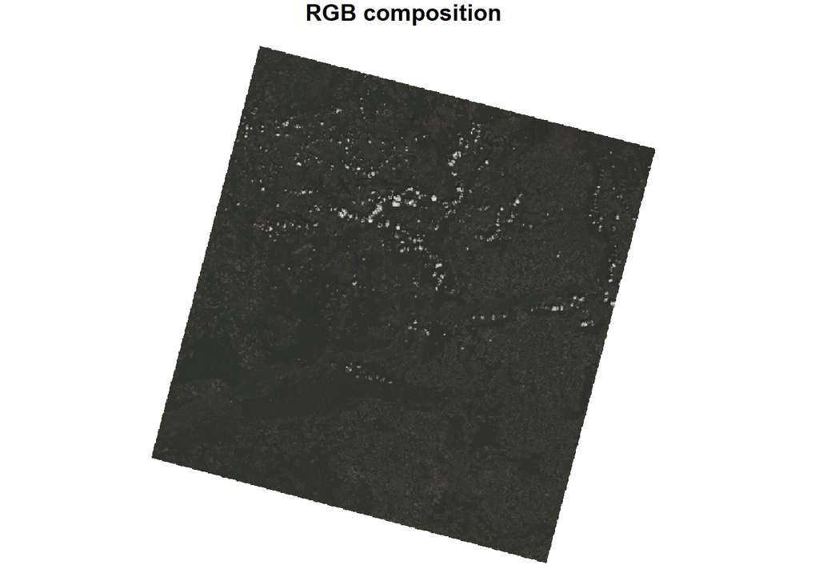

```r
plot(rasters, rgb = c(3, 2, 1), downsample = 10, main = "RGB composition")
```

## Sampling

For modeling, we need to use a smaller sample rather than the entire dataset. Sampling training points consists of several steps, which are shown below:

```r
bbox = st_as_sfc(st_bbox(rasters)) # define a bounding box
smp = st_sample(bbox, size = 20000) # sample points from the extent of the polygon
smp = st_extract(rasters, smp) # extract the pixel values for those points
smp = st_drop_geometry(st_as_sf(smp)) # convert to a data frame (remove geometry)
smp = na.omit(smp) # remove missing values (NA)
head(smp)
```

```
##   Blue Green   Red   NIR
## 1 9908 11349 11862 19186
## 2 8187  9252  8641 21080
## 3 9377 10576 10837 15875
## 6 9264 10154 10422 13587
## 8 7571  8276  8065 11121
## 9 8090  8799  8162 20219
```

## Modelling

The aim of our analysis is to perform unsupervised classification (clustering) of raster pixels based on spectral bands. In other words, we want to group similar cells together to make homogeneous clusters. A popular method is the Gaussian mixture models available in the **mclust** package. Clustering can be done using the `Mclust()` function and requires the target number of clusters to be defined in advance (e.g. `G = 6`).

```r
library("mclust")
mdl = Mclust(smp, G = 6) # train the model
```

## Prediction

As stated earlier, the entire raster is too large to be loaded into memory. We need to split it into smaller blocks. For this, we can use the `st_tile()` function, which requires the total number of rows and columns, and the number of rows and columns of a small block (for example, it could be 2048 x 2048, but usually we should find the optimal size).

```r
tiles = st_tile(nrow(rasters), ncol(rasters), 2048, 2048)
head(tiles)
```

```
##      nXOff nYOff nXSize nYSize
## [1,]     1     1   2048   2048
## [2,]     1  2049   2048   2048
## [3,]     1  4097   2048   2048
## [4,]     1  6145   2048   1807
## [5,]  2049     1   2048   2048
## [6,]  2049  2049   2048   2048
```

Finally, the input raster will be divided into 16 smaller blocks. In the following sections, we will compare the processing performance of one versus multiple processes.

Now let’s discuss what steps we need to take to make a prediction:

1. We have 16 blocks, so we need to make predictions in a loop.
2. We have to load the rasters, but this time into memory (`proxy = FALSE`) and only the block (`RasterIO = tiles[iterator, ]`).
3. We use the `predict()` function for clustering. Note we need to define the `drop_dimensions = TRUE` argument to remove the coordinates from the data frame.
4. Finally, we have to save the clustering results to disk (it can be a temporary directory). Be sure to specify the missing values (`NA_value = 0`) and the block size as the input (`chunk_size = dim(tile)`).

**Note!** The `read_stars()` function opens the connection to the file and closes it each time, which causes overhead. With a large number of blocks, this can significantly affect performance. In this case, it is better to use a low-level API, e.g. **gdalraster**. The second difference between these packages is that **gdalraster** allows loading data stored as integers, while **stars** loads it as real (floating point) by default, so we can practically save half of the memory.

### Single process

```r
start_time = Sys.time()

for (i in seq_len(nrow(tiles))) {
  tile = read_stars(files, proxy = FALSE, RasterIO = tiles[i, ])
  names(tile) = bands # rename bands

  pr = predict(tile, mdl, drop_dimensions = TRUE)
  pr = pr[1] # select only clusters from output
  save_path = file.path(tempdir(), paste0("tile_", i, ".tif"))
  write_stars(pr, save_path, NA_value = 0, options = "COMPRESS=NONE",
              type = "Byte", chunk_size = dim(tile))
}

end_time_1 = difftime(Sys.time(), start_time, units = "secs")
end_time_1 = round(end_time_1)
```

The prediction took 477 seconds.

### Multiple processes

Multi-process prediction is a bit more complicated. This requires the use of two additional packages, i.e. **foreach** and **doParallel**. Now we need to setup a parallel backend by defining the number of available cores (or by detecting them automatically using `detectCores()`) in `makeCluster()`, and then registering the cluster using the `registerDoParallel()` function. This can be accomplished, for instance, with:

```r
library("foreach")
library("doParallel")
cores = 3 # specify number of cores
cl = makeCluster(cores)
registerDoParallel(cl)
```

Once we have the computing cluster prepared, we can write a loop that will be executed in parallel. Instead of the standard `for()` loop, we will use `foreach()` with the `%dopar%` operator. In `foreach()` we need to define an iterator and packages that will be exported to each worker. Then we use the `%dopar%` operator and write the core of the function (is identical to the example using a single process).

```r
packages = c("stars", "mclust")

start_time = Sys.time()

tifs = foreach(i = seq_len(nrow(tiles)), .packages = packages) %dopar% {
  tile = read_stars(files, proxy = FALSE, RasterIO = tiles[i, ], NA_value = 0)
  names(tile) = bands

  pr = predict(tile, mdl, drop_dimensions = TRUE)
  pr = pr[1]
  save_path = file.path(tempdir(), paste0("tile_", i, ".tif"))
  write_stars(pr, save_path, NA_value = 0, options = "COMPRESS=NONE",
              type = "Byte", chunk_size = dim(tile))
  return(save_path)
}

end_time_2 = difftime(Sys.time(), start_time, units = "secs")
end_time_2 = round(end_time_2)
```

The prediction took 245 seconds. By using three processes instead of one, we have cut the operation time by half!

## Post-processing

We have our raster blocks saved in a temporary directory. The final step is to make a mosaic (that is, to combine the blocks into a single raster). I recommend using GDAL tools, as they provide the best performance when there are a large number of blocks. We can use:

1. `buildvrt` to create a virtual mosaic.
2. `translate` to save as a geotiff.

We can call these tools using the `gdal_utils()` function from the **sf** package.

```r
vrt = tempfile(fileext = ".vrt")
gdal_utils(util = "buildvrt", unlist(tifs), destination = vrt)
gdal_utils(util = "translate", vrt, destination = "predict.tif")
```

Once the parallel computation is complete, we can close the computing cluster using `stopCluster()` function (this will delete the temporary files).

```r
stopCluster(cl)
```

So let’s see what our final map looks like.

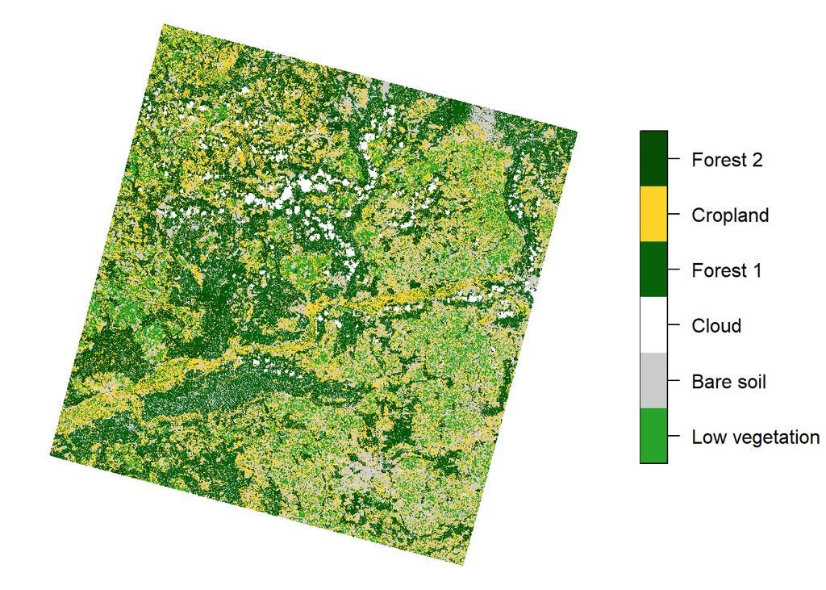

```r
clustering = read_stars("predict.tif")
colors = c("#29a329", "#cbcbcb", "#ffffff", "#086209", "#fdd327", "#064d06")
names = c("Low vegetation", "Bare soil", "Cloud", "Forest 1", "Cropland", "Forest 2")
clustering[[1]] = factor(clustering[[1]], labels = names)
plot(clustering, main = NULL, col = colors, key.width = lcm(4))
```